# Predição de vida remanescente de motores a jato: Uma Abordagem de Aprendizado de Máquina

Tomás Silva

2023-09-21

```r
#library(reticulate)
#install.packages("remotes")
#remotes::install_github(sprintf("rstudio/%s", c("reticulate", "tensorflow", "keras")))
#install_miniconda()
#library(keras)
#install_keras()

#tensorflow::as_tensor("Hello World")
```

## Carregamento e entendimento das bases de dados

Há 4 bases de treinamento, cada uma para uma condição de uso.

```r
train_file <- "Turbo fan dataset/CMaps/train_FD001.txt"
test_file <- "Turbo fan dataset/CMaps/test_FD001.txt"
RUL_file <- "Turbo fan dataset/CMaps/RUL_FD001.txt"

#Carregamento das base de dados em tibbles
train_df <- tibble(read.delim(train_file, header = FALSE, sep = " "))
test_df <- tibble(read.delim(test_file, header = FALSE, sep = " "))
y_test <- tibble(read.delim(RUL_file, header = FALSE, sep = " "))

#Criação de numeração para os dados de sensoriamento
sensor_names <- c("(Fan inlet temperature) (◦R)",
"(LPC outlet temperature) (◦R)",
"(HPC outlet temperature) (◦R)",
"(LPT outlet temperature) (◦R)",
"(Fan inlet Pressure) (psia)",
"(bypass-duct pressure) (psia)",
"(HPC outlet pressure) (psia)",
"(Physical fan speed) (rpm)",
"(Physical core speed) (rpm)",
"(Engine pressure ratio(P50/P2)",
"(HPC outlet Static pressure) (psia)",
"(Ratio of fuel flow to Ps30) (pps/psia)",
"(Corrected fan speed) (rpm)",
"(Corrected core speed) (rpm)",
"(Bypass Ratio) ",
"(Burner fuel-air ratio)",
"(Bleed Enthalpy)",
"(Required fan speed)",
"(Required fan conversion speed)",
"(High-pressure turbines Cool air flow)",
"(Low-pressure turbines Cool air flow)")

sensor_n <- c()
for (x in 1:21){
  new_sensor <- paste(c("s", x#, "_",sensor_names[x]
                        ), collapse = "")
  sensor_n <- append(sensor_n, new_sensor)
  }

sensors_dict <- hash(sensor_n,sensor_names)

#Alteração do nome das colunas do dataset
colnames <- c("engine_id", "cycles", "altitude", "mach", "tra", sensor_n)
colnames(train_df) <- colnames
colnames(test_df) <- colnames
```

```r
#Remoção das colunas sem dados
train <- train_df[,colSums(is.na(train_df)) < nrow(train_df)]
test <- test_df[,colSums(is.na(test_df)) < nrow(test_df)]
y_test <- y_test[,colSums(is.na(y_test)) < nrow(y_test)]
```

Adição da RUL à base de treinamento e de testes.

```r
#A base de treinamento possui dados dos sensores até a falha, ou seja,o maior ciclo presente no banco de dados é o ciclo em que a falha aconteceu. Logo, a RUL em cada instante é o maior ciclo registrado do motor subtraído do ciclo de cada instante:
train <- train %>%
  group_by(engine_id) %>%
  mutate(RUL = max(cycles) - cycles) %>%
  ungroup()

#A base de testes possui apenas parte do ciclo de vida de cada motor, a real RUL de cada um após o último instante na base de testes está na base y_test.

engine_id <- 1:100
y_test <- y_test %>%
  mutate(engine_id = engine_id) %>%
  rename(True_RUL = V1)


test <- test %>%
  left_join(y_test, by = "engine_id") %>%
  group_by(engine_id) %>%
  mutate(RUL1 = max(cycles) - cycles) %>%
  mutate(RUL = RUL1 + True_RUL) %>%
  ungroup() %>%
  select(-True_RUL, -RUL1)
```

### Estatísticas descritivas

```r
train_description <- as.data.frame(do.call(cbind, lapply(train, summary)))
test_description <- as.data.frame(do.call(cbind, lapply(test, summary)))

library(kableExtra)
train_description %>%
  select(-RUL, -engine_id) %>%
  round(2) %>%
  kbl(caption = "Estatísticas descritivas") %>%
  kable_styling(bootstrap_options = c("striped", "hover"))
```

Estatísticas descritivas

|  | cycles | altitude | mach | tra | s1 | s2 | s3 | s4 | s5 | s6 | s7 | s8 | s9 | s10 | s11 | s12 | s13 | s14 | s15 | s16 | s17 | s18 | s19 | s20 | s21 |
| --- | --- | --- | --- | --- | --- | --- | --- | --- | --- | --- | --- | --- | --- | --- | --- | --- | --- | --- | --- | --- | --- | --- | --- | --- | --- |
| Min. | 1.00 | -0.01 | 0 | 100 | 518.67 | 641.21 | 1571.04 | 1382.25 | 14.62 | 21.60 | 549.85 | 2387.90 | 9021.73 | 1.3 | 46.85 | 518.69 | 2387.88 | 8099.94 | 8.32 | 0.03 | 388.00 | 2388 | 100 | 38.14 | 22.89 |
| 1st Qu. | 52.00 | 0.00 | 0 | 100 | 518.67 | 642.32 | 1586.26 | 1402.36 | 14.62 | 21.61 | 552.81 | 2388.05 | 9053.10 | 1.3 | 47.35 | 520.96 | 2388.04 | 8133.24 | 8.41 | 0.03 | 392.00 | 2388 | 100 | 38.70 | 23.22 |
| Median | 104.00 | 0.00 | 0 | 100 | 518.67 | 642.64 | 1590.10 | 1408.04 | 14.62 | 21.61 | 553.44 | 2388.09 | 9060.66 | 1.3 | 47.51 | 521.48 | 2388.09 | 8140.54 | 8.44 | 0.03 | 393.00 | 2388 | 100 | 38.83 | 23.30 |
| Mean | 108.81 | 0.00 | 0 | 100 | 518.67 | 642.68 | 1590.52 | 1408.93 | 14.62 | 21.61 | 553.37 | 2388.10 | 9065.24 | 1.3 | 47.54 | 521.41 | 2388.10 | 8143.75 | 8.44 | 0.03 | 393.21 | 2388 | 100 | 38.82 | 23.29 |
| 3rd Qu. | 156.00 | 0.00 | 0 | 100 | 518.67 | 643.00 | 1594.38 | 1414.55 | 14.62 | 21.61 | 554.01 | 2388.14 | 9069.42 | 1.3 | 47.70 | 521.95 | 2388.14 | 8148.31 | 8.47 | 0.03 | 394.00 | 2388 | 100 | 38.95 | 23.37 |
| Max. | 362.00 | 0.01 | 0 | 100 | 518.67 | 644.53 | 1616.91 | 1441.49 | 14.62 | 21.61 | 556.06 | 2388.56 | 9244.59 | 1.3 | 48.53 | 523.38 | 2388.56 | 8293.72 | 8.58 | 0.03 | 400.00 | 2388 | 100 | 39.43 | 23.62 |

```r
train_description <-
  train_description %>%
  filter(rownames(train_description) == "Median" | rownames(train_description) == "Min."| rownames(train_description) == "Max.") %>%
  rownames_to_column(var = "Statistics") %>%
  pivot_longer(cols = -Statistics,names_to = "Sensor", values_to = "train_value") %>%
  select(2,1,3) %>%
  arrange(Sensor)

test_description <-
  test_description %>%
  filter(rownames(test_description) == "Median" | rownames(test_description) == "Min."| rownames(test_description) == "Max.") %>%
  rownames_to_column(var = "Statistics") %>%
  pivot_longer(cols = -Statistics,names_to = "Sensor", values_to = "test_value") %>%
  select(2,1,3) %>%
  arrange(Sensor)

sensor_description <- merge(train_description, test_description, by=c("Sensor", "Statistics"))

#Há sensores que não apresentaram variação nas medições. Colunas serão removidas dos datasets:
summary(train)
```

```
##    engine_id          cycles         altitude              mach
##  Min.   :  1.00   Min.   :  1.0   Min.   :-8.70e-03   Min.   :-6.000e-04
##  1st Qu.: 26.00   1st Qu.: 52.0   1st Qu.:-1.50e-03   1st Qu.:-2.000e-04
##  Median : 52.00   Median :104.0   Median : 0.00e+00   Median : 0.000e+00
##  Mean   : 51.51   Mean   :108.8   Mean   :-8.87e-06   Mean   : 2.351e-06
##  3rd Qu.: 77.00   3rd Qu.:156.0   3rd Qu.: 1.50e-03   3rd Qu.: 3.000e-04
##  Max.   :100.00   Max.   :362.0   Max.   : 8.70e-03   Max.   : 6.000e-04
##       tra            s1              s2              s3             s4
##  Min.   :100   Min.   :518.7   Min.   :641.2   Min.   :1571   Min.   :1382
##  1st Qu.:100   1st Qu.:518.7   1st Qu.:642.3   1st Qu.:1586   1st Qu.:1402
##  Median :100   Median :518.7   Median :642.6   Median :1590   Median :1408
##  Mean   :100   Mean   :518.7   Mean   :642.7   Mean   :1591   Mean   :1409
##  3rd Qu.:100   3rd Qu.:518.7   3rd Qu.:643.0   3rd Qu.:1594   3rd Qu.:1415
##  Max.   :100   Max.   :518.7   Max.   :644.5   Max.   :1617   Max.   :1441
##        s5              s6              s7              s8             s9
##  Min.   :14.62   Min.   :21.60   Min.   :549.9   Min.   :2388   Min.   :9022
##  1st Qu.:14.62   1st Qu.:21.61   1st Qu.:552.8   1st Qu.:2388   1st Qu.:9053
##  Median :14.62   Median :21.61   Median :553.4   Median :2388   Median :9061
##  Mean   :14.62   Mean   :21.61   Mean   :553.4   Mean   :2388   Mean   :9065
##  3rd Qu.:14.62   3rd Qu.:21.61   3rd Qu.:554.0   3rd Qu.:2388   3rd Qu.:9069
##  Max.   :14.62   Max.   :21.61   Max.   :556.1   Max.   :2389   Max.   :9245
##       s10           s11             s12             s13            s14
##  Min.   :1.3   Min.   :46.85   Min.   :518.7   Min.   :2388   Min.   :8100
##  1st Qu.:1.3   1st Qu.:47.35   1st Qu.:521.0   1st Qu.:2388   1st Qu.:8133
##  Median :1.3   Median :47.51   Median :521.5   Median :2388   Median :8141
##  Mean   :1.3   Mean   :47.54   Mean   :521.4   Mean   :2388   Mean   :8144
##  3rd Qu.:1.3   3rd Qu.:47.70   3rd Qu.:522.0   3rd Qu.:2388   3rd Qu.:8148
##  Max.   :1.3   Max.   :48.53   Max.   :523.4   Max.   :2389   Max.   :8294
##       s15             s16            s17             s18            s19
##  Min.   :8.325   Min.   :0.03   Min.   :388.0   Min.   :2388   Min.   :100
##  1st Qu.:8.415   1st Qu.:0.03   1st Qu.:392.0   1st Qu.:2388   1st Qu.:100
##  Median :8.439   Median :0.03   Median :393.0   Median :2388   Median :100
##  Mean   :8.442   Mean   :0.03   Mean   :393.2   Mean   :2388   Mean   :100
##  3rd Qu.:8.466   3rd Qu.:0.03   3rd Qu.:394.0   3rd Qu.:2388   3rd Qu.:100
##  Max.   :8.585   Max.   :0.03   Max.   :400.0   Max.   :2388   Max.   :100
##       s20             s21             RUL
##  Min.   :38.14   Min.   :22.89   Min.   :  0.0
##  1st Qu.:38.70   1st Qu.:23.22   1st Qu.: 51.0
##  Median :38.83   Median :23.30   Median :103.0
##  Mean   :38.82   Mean   :23.29   Mean   :107.8
##  3rd Qu.:38.95   3rd Qu.:23.37   3rd Qu.:155.0
##  Max.   :39.43   Max.   :23.62   Max.   :361.0
```

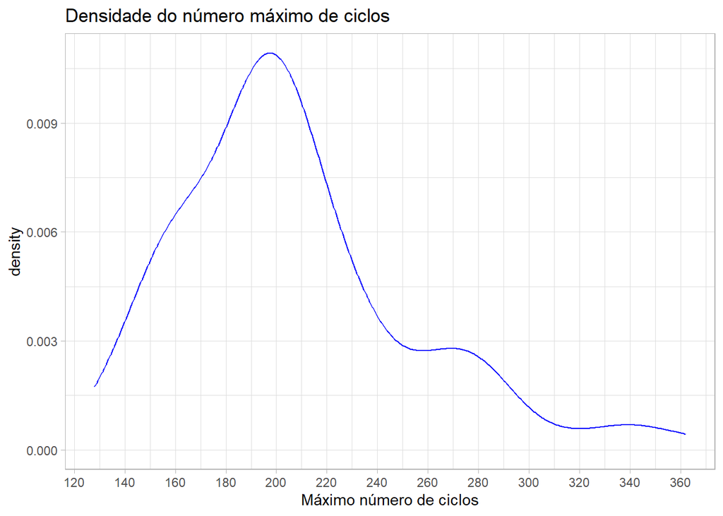

```r
train <- train %>% select(1:4,where(~ max(.x) - min(.x) !=0))

#Observação do comportamento do número máximo de ciclos de cada motor:
train %>% group_by(engine_id) %>% summarise(max_cycles = max(cycles)) %>%
  ggplot()+
  geom_density(mapping = aes(x = max_cycles), color = "blue") +
  theme_light() +
  labs(title = "Densidade do número máximo de ciclos") +
  xlab("Máximo número de ciclos") +
  theme(plot.subtitle = element_text(hjust = 0.5))+
  scale_x_continuous(breaks = seq(120,380,20))
```

```r
train %>% group_by(engine_id) %>% summarise(max_cycles = max(cycles)) %>% summary()
```

```
##    engine_id        max_cycles
##  Min.   :  1.00   Min.   :128.0
##  1st Qu.: 25.75   1st Qu.:177.0
##  Median : 50.50   Median :199.0
##  Mean   : 50.50   Mean   :206.3
##  3rd Qu.: 75.25   3rd Qu.:229.2
##  Max.   :100.00   Max.   :362.0
```

Observa-se que a maior parte (75%) dos motores teve número de ciclos inferior a 229.2, e o número mínimo é 128. Metade dos motores teve vida entre 177 e 229.2 ciclos

## Preparação dos dados

### Análise e seleção de atributos

Análise de correlação entre os sensores e dos sensores com a RUL, considerando um nível de significância de 5% :

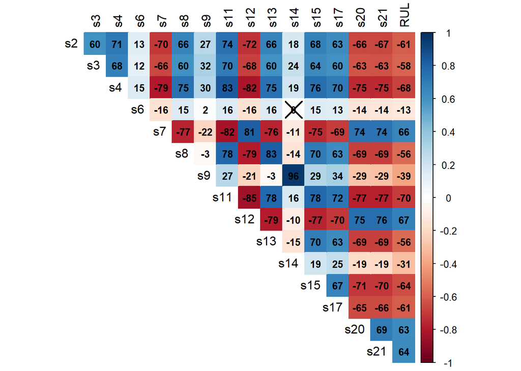

```r
cor_train <- rcorr(as.matrix(train[5:length(train)]))
r_matrix <- cor_train$r
p_matrix <- cor_train$P
#cor_train <- cor(train[6:21], method = "pearson")

corrplot::corrplot(corr = r_matrix, method = "color", type = "upper", addCoef.col = "black", diag= F, addCoefasPercent = T, tl.col = "black", number.cex = 0.8, p.mat = p_matrix, sig.level = 0.05, insig = "pch")
```

O sensor 6 tem baixa (-0.13) correlação com a RUL, enquanto que os sensores 9 e 14 tem alta (0.96) correlação entre si. Eles são a (Physical core speed) e (Corrected core speed), o que indica que somente um deles pode ser suficiente para a criação do modelo.

Os sensores 6 e 14 serão removidos da base para simplificá-la:

```r
values(sensors_dict, keys = c("s9", "s14"))
```

```
##                             s9                            s14
##  "(Physical core speed) (rpm)" "(Corrected core speed) (rpm)"
```

```r
train <- train %>% select(-s6, -s14)

colunas_treino <- colnames(train) #Vetor com as colunas presentes na base de treino após as reduçoes realizadas
test <- test %>% select(all_of(colunas_treino))
```

Observação do comportamento dos dados dos sensores

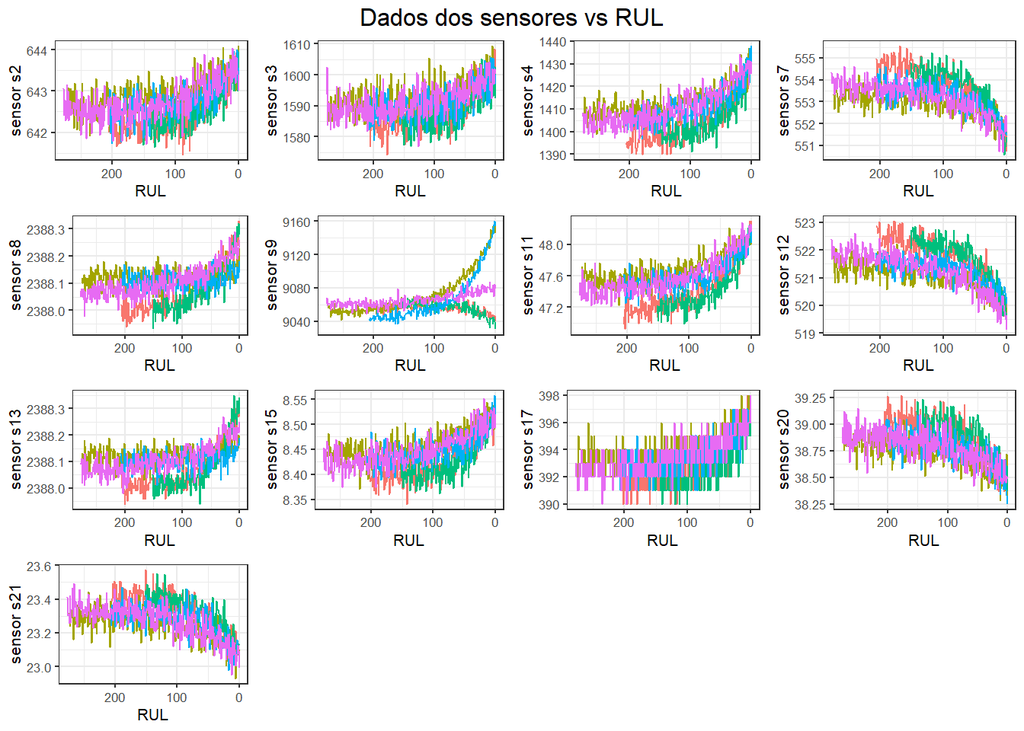

```r
lista_aleatoria <- sample.int(100,5,replace = F)

train_simplificada <- train %>% filter(engine_id %in% lista_aleatoria)
lista_plot <- list()
for (i in 5:(length(train_simplificada)-1)){
  s <- tibble()
  s <- train_simplificada %>% select(engine_id,i,length(train_simplificada)) %>% rename(sensor = 2)
  lista_plot[[paste0("plot", i)]] <- ggplot(data = s)+
    geom_line(mapping = aes(x = RUL, y = sensor, color = factor(engine_id)), show.legend = F)+
    scale_x_reverse()+
    theme_bw(base_size=8) +
    labs(y=paste("sensor",colnames(train_simplificada)[i]))
}

do.call("grid.arrange", c(lista_plot, top = "Dados dos sensores vs RUL"))
```

Nota-se que os sensores 2, 3, 4, 8, 9, 11,13, 15 e 17 tem comportamento crescente com o passar dos ciclos de funcionamento e, consequentemente, um aumento do seu valor está relacionado à redução da RUL. Já os sensores 7, 12, 20 e 21 possuem comportamento decrescente com a RUL.

### Filtragem dos dados com base nas medianas móveis

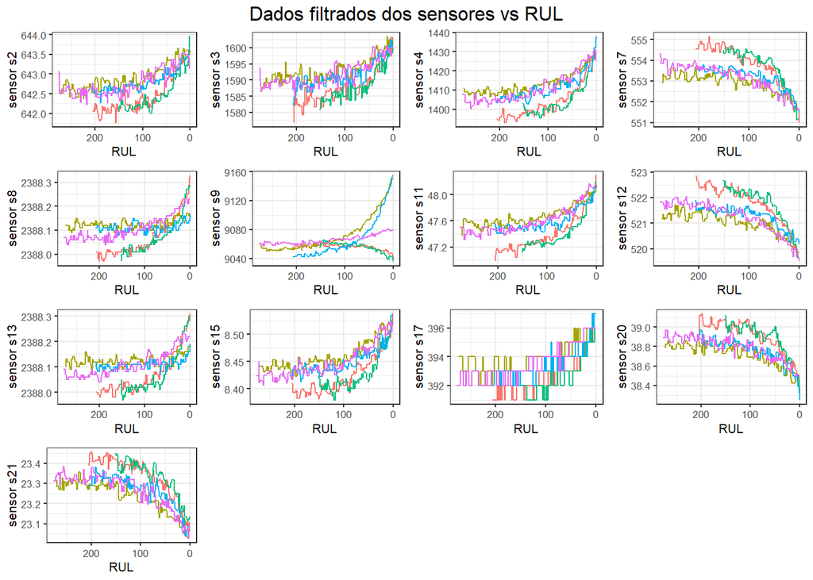

```r
median_filter <- function(x, k=7){runmed(x,k)} #Median Filter

#base de treinamento
train_filtered <- ddply(train,.(engine_id),function(x)
  {
    sapply(x[,5:17],function(y) median_filter(y))
  })
train_filtered <- as_tibble(cbind(train[1:2], train_filtered[2:14], train[18]))

#base de teste
test_filtered <- ddply(test,.(engine_id),function(x)
  {
    sapply(x[,5:17],function(y) median_filter(y))
  })
test_filtered <- as_tibble(cbind(test[,1:2], test_filtered[2:14], test[18]))


#Visualização do comportamento dos sensores
train_simplificada <- train_filtered %>% filter(engine_id %in% lista_aleatoria)
lista_plot <- list()
for (i in 3:(length(train_simplificada)-1)){
  s <- tibble()
  s <- train_simplificada %>% select(engine_id,i,length(train_simplificada)) %>% rename(sensor = 2)
  lista_plot[[paste0("plot", i)]] <- ggplot(data = s)+
    geom_line(mapping = aes(x = RUL, y = sensor, color = factor(engine_id)), show.legend = F)+
    scale_x_reverse()+
    theme_bw(base_size=8) +
    labs(y=paste("sensor",colnames(train_simplificada)[i]))
}

do.call("grid.arrange", c(lista_plot, top = "Dados filtrados dos sensores vs RUL"))
```

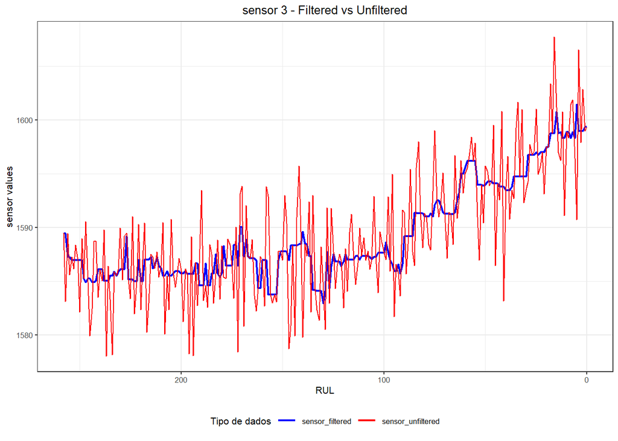

```r
#Visualização do comportamento dos dados do sensor 3 após a aplicação do filtro de medianas móveis
train_temp <-  train_filtered %>%
  filter(engine_id==7) %>%
  select(1,s3, RUL) %>%
  mutate(sensor_filtered = s3, .keep = "unused")

train_temp <-  train %>%
  filter(engine_id==7) %>%
  select(s3) %>%
  mutate(sensor_unfiltered = s3, .keep = "unused") %>%
  cbind(train_temp)

ggplot(data = train_temp,aes(x = RUL))+
    geom_line(mapping = aes(y = sensor_filtered, color = "sensor_filtered"),linewidth = 0.8)+
    geom_line(mapping = aes(y = sensor_unfiltered, color = "sensor_unfiltered"),linewidth = 0.5)+
    scale_color_manual(name = "Tipo de dados", values = c("sensor_filtered" = "blue", "sensor_unfiltered" = "red"))+
    scale_x_reverse()+
    labs(y="sensor values",title="sensor 3 - Filtered vs Unfiltered")+
    theme_bw(base_size=8)+
    theme(plot.title = element_text(hjust = 0.5),legend.position = "bottom", legend.direction = "horizontal")
```

Pode-se identificar que há, visualmente, menos ruído nos dados e vários “outliers” foram suavizados após a aplicação do filtro de medianas móveis.

### Padronização das bases de dados

```r
#Base de treinamento
mean <- lapply(train_filtered, mean)
std <- lapply(train_filtered, sd)

train_scaled <- as_tibble(scale(train_filtered,center = mean, scale = std))
train_scaled <- cbind(train_filtered[1], train_scaled[,2:15], train_filtered[16])
test_scaled <- as_tibble(scale(test_filtered,center = mean, scale = std))
test_scaled <- cbind(test_filtered[1], test_scaled[,2:15], test_filtered[16])
```

O Histograma após a padronização dos dados demonstra que essa técnica faz com que variação dos dados se restrinja a uma faixa de valores de mesma grandeza, com média 0 e desvio padrão igual a 1.

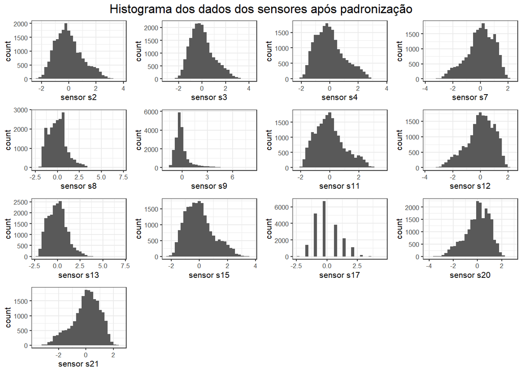

```r
lista_plot <- list()
for (i in 3:(length(train_scaled)-1)){
  s <- tibble()
  s <- train_scaled %>% select(i) %>% rename(sensor = 1)
  lista_plot[[paste0("plot", i)]] <- ggplot(data = s, aes(sensor))+
    geom_histogram(show.legend = FALSE)+
    theme_bw(base_size=8) +
    labs(x=paste("sensor",colnames(train_scaled)[i]))
}

do.call("grid.arrange", c(lista_plot, top = "Histograma dos dados dos sensores após padronização"))
```

### Definição da função erro

```r
score <- function (y_true, y_pred, a1 = 13, a2 = 10){
            d <- y_pred - y_true
            n <- nrow(y_true)
            score <- 0
            for (i in d) {
              if(i<0){
                score <- score + exp(-i/a1) - 1
              } else {
                score <- score + exp(i/a2) - 1
              }
            }
          score
          }

func_score <- function(y_true, y_pred, tipo = "treino"){
            list_scores <- list(round(score(y_true, y_pred),2),
                            round(mae(y_true, y_pred),2),
                            round(rmse(y_true, y_pred),2))
            if (tipo == "treino"){
            cat("Mean Absolute Error: ",list_scores[[2]],"\n",
                "Root Mean Squared Error: ", list_scores[[3]], sep = "")
            } else {
            cat("Score: ", list_scores[[1]],"\n",
                "Mean Absolute Error: ",list_scores[[2]],"\n",
                "Root Mean Squared Error: ", list_scores[[3]], sep = "")
            }
}
```

Criação dos modelos supervisionados

### Preparação da base de testes

Somente as colunas usadas para o treinamento são mantidas. Além disso, só será usado a linha com o último ciclo monitorado para comparar a RUL predita com a RUL real.

```r
test_end_cycle <- test_scaled %>%
  group_by(engine_id) %>%
  mutate(max = max(cycles)) %>%
  ungroup() %>%
  filter(cycles == max) %>%
  select(-max, -engine_id)
```

Função para plotar os gráficos de comparação de resultados e de Histograma de Erros

```r
plot_results <- function(results_df, metodo = "Modelo base", stat = c("Critical", "Non Critical")){

lista_plot <- list()

df <- results_df %>%
  filter(method == metodo) %>%
  filter(status %in% stat)


lista_plot[["Gráfico de comparação"]] <- df %>%
  ggplot(mapping = aes(x = engine_id)) +
  geom_line(mapping = aes(y = y_true), linewidth = 0.7,linetype = 1, colour = "gray") +
  geom_point(mapping = aes(y = y_true, colour = "True RUL"), shape = 22, fill = "blue") +
  geom_line(mapping = aes(y = y_pred),linewidth = 0.5, linetype = 3, colour = "gray") +
  geom_point(mapping = aes(y = y_pred, colour = prediction_type)) +
  labs(x = "engine id", y = "RUL - Cycles", title = "Gráfico (a) - Comparação de resultados")+
  theme_light() +
  scale_colour_manual(" ", values=c("#E69F00", "darkred", "blue"))+
  scale_y_continuous(limits = c(0, NA))+
  theme(legend.position = "bottom", legend.title = element_blank(), legend.key=element_blank(),plot.title = element_text(hjust = 0.5))


lista_plot[["Histograma de erros"]] <- df %>%
  ggplot(mapping = aes( error)) +
  geom_histogram(show.legend = FALSE)+
  theme_bw(base_size=8)+
  labs(title = "Gráfico (b) - Histograma de erros")+
  theme_light() +
  theme(plot.title = element_text(hjust = 0.5))+
  scale_x_continuous(limits = ~ c(-1, 1) * max(abs(.x)))+
  labs (caption = paste0("Range de erros: ", round(min(df$error), 2), " a ",round(max(df$error), 2)))

do.call("grid.arrange", c(lista_plot, ncol = 2))
}
```

### Modelo de referência

```r
media_RUL <- train_scaled %>% group_by(engine_id) %>% summarise(max_RUL = max(RUL)) %>% summarise(mean = mean(max_RUL))
media_RUL <- as.integer(media_RUL)

train_mb <- train_filtered %>% mutate(RUL_pred = media_RUL - cycles) %>% mutate(RUL_pred = ifelse(RUL_pred <= 0, 0, RUL_pred)) %>% select(engine_id, RUL,RUL_pred)
func_score(train_mb$RUL,train_mb$RUL_pred)
```

```
## Mean Absolute Error: 34.13
## Root Mean Squared Error: 46.55
```

```r
test_mb <- test_filtered %>% mutate(RUL_pred = media_RUL - cycles) %>% mutate(RUL_pred = ifelse(RUL_pred <= 0, 0, RUL_pred)) %>% select(engine_id, RUL,RUL_pred)
func_score(test_mb$RUL,test_mb$RUL_pred)
```

```
## Mean Absolute Error: 36.16
## Root Mean Squared Error: 48.13
```

```r
y_test_mb_end <- test_mb %>% group_by(engine_id) %>%
  mutate(min = min(RUL)) %>%
  ungroup() %>%
  filter(RUL == min) %>%
  select(engine_id, RUL,RUL_pred)
func_score(y_test_mb_end$RUL,y_test_mb_end$RUL_pred, "teste")
```

```
## Score: 25454.54
## Mean Absolute Error: 31.83
## Root Mean Squared Error: 40.05
```

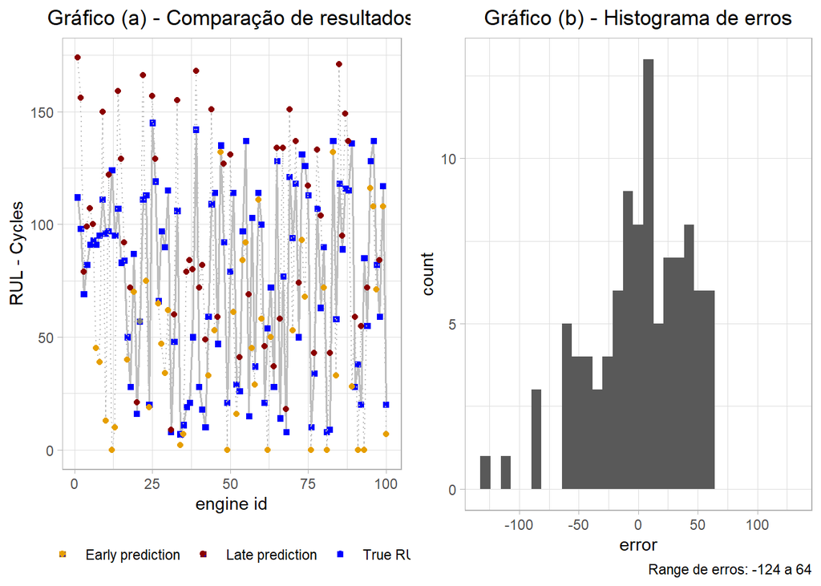

```r
#Compilação dos resultados
results <- tibble()
results_mb <- tibble(engine_id = 1:100,
                  method = "Modelo base",
                  y_true = y_test_mb_end$RUL,
                  y_pred = y_test_mb_end$RUL_pred,
                  prediction_type = case_when(y_pred>y_true ~ "Late prediction",
                                              y_pred<y_true ~ "Early prediction"),
                  error = y_pred - y_true) %>%
  mutate(status = case_when(y_true < 50 ~ "Critical",y_true >= 50 ~ "Non Critical"))

results <- results_mb

plot_results(results, metodo = "Modelo base")
```

### Modelo de Random Forest

```r
#Treinamento do modelo e Importance Analysis
set.seed(12)
rf_fit <- randomForest(RUL~.-engine_id -cycles,data = train_scaled)
rf_fit
```

```
##
## Call:
##  randomForest(formula = RUL ~ . - engine_id - cycles, data = train_scaled)
##                Type of random forest: regression
##                      Number of trees: 500
## No. of variables tried at each split: 4
##
##           Mean of squared residuals: 677.9311
##                     % Var explained: 85.71
```

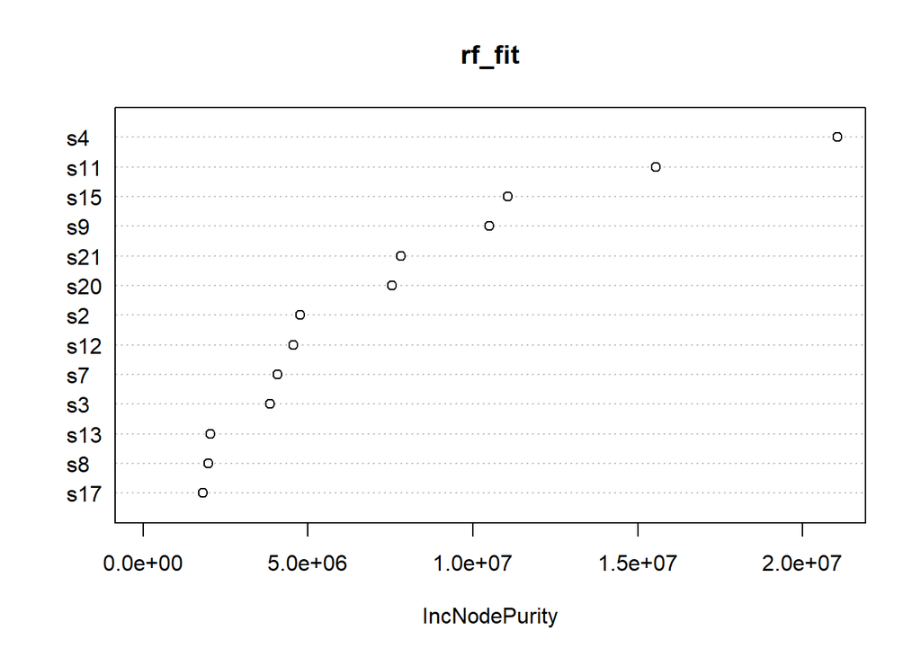

```r
varImpPlot(rf_fit)
```

```r
importance(rf_fit)
```

```
##     IncNodePurity
## s2        4760831
## s3        3858706
## s4       21056335
## s7        4078960
## s8        1976609
## s9       10499122
## s11      15541787
## s12       4553018
## s13       2033738
## s15      11049918
## s17       1814450
## s20       7555052
## s21       7822222
```

```r
#Análise dos resultados da base de treinamento
y_train_rf <- predict(rf_fit)
y_train_true <- as.numeric(train_scaled$RUL)
func_score(y_train_true, y_train_rf)
```

```
## Mean Absolute Error: 17.42
## Root Mean Squared Error: 26.04
```

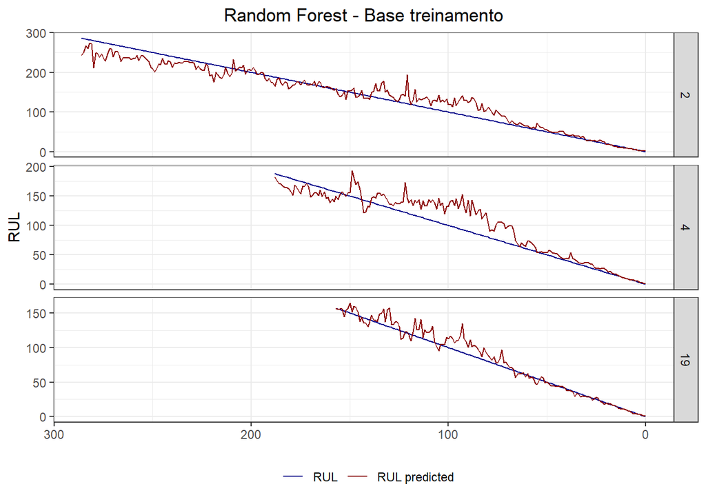

```r
train_rf <- train_scaled %>%  select(engine_id, RUL) %>% mutate(RUL_pred = y_train_rf)

engine_samples <- sample(1:100,3)
train_rf %>% filter(engine_id %in% engine_samples) %>%
  ggplot(aes(x=RUL))+
  geom_line(aes(y=RUL,color = "RUL"))+
  geom_line(aes(y=RUL_pred,color = "RUL predicted"))+
  scale_x_reverse()+
  labs(x = NULL, title = "Random Forest - Base treinamento")+
  scale_colour_manual(" ", values=c("darkblue", "darkred"))+
  theme_bw()+
  theme(legend.position = "bottom",legend.title = element_blank(), legend.key=element_blank(),plot.title = element_text(hjust = 0.5))+
  facet_grid(rows = vars(engine_id), scales ="free")
```

```r
#Análise dos resultados da base de teste - Completa
y_test_rf <- predict(rf_fit,test_scaled)
y_test_true <- as.numeric(test_scaled$RUL)
func_score(y_test_true,y_test_rf)
```

```
## Mean Absolute Error: 34.67
## Root Mean Squared Error: 46.38
```

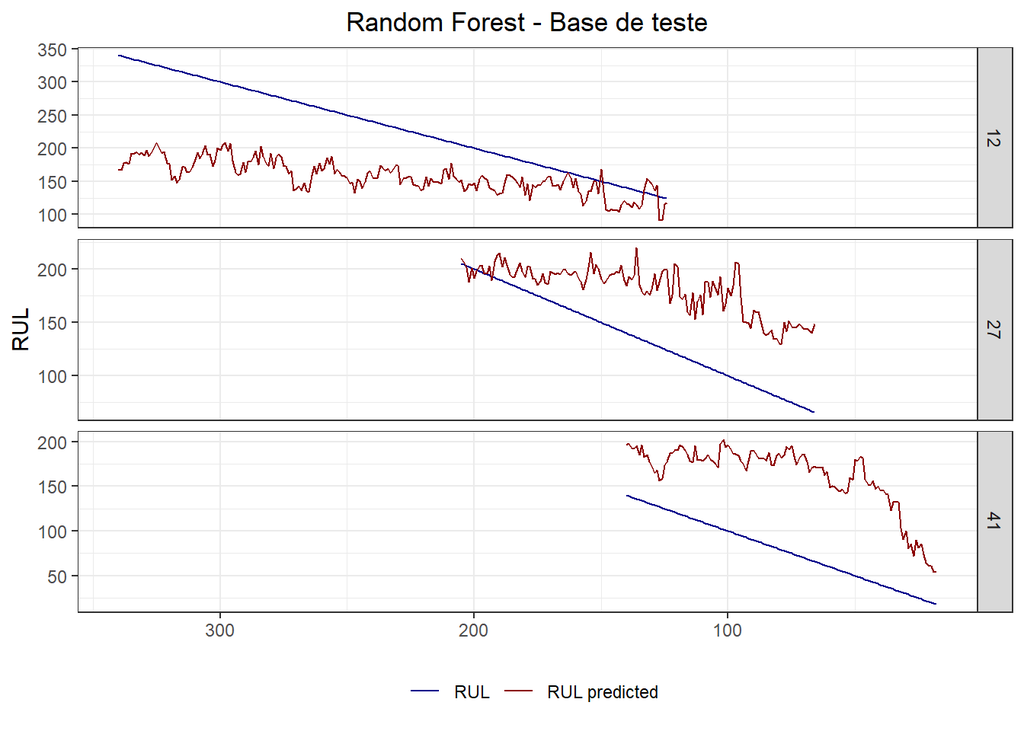

```r
test_RUL_initial <- test_scaled %>% group_by(engine_id) %>% summarise(max = max(RUL)) %>% arrange(max) #Escolha de 3 motores dessa base para análise gráfica
engine_samples <- c(41,27,12)

test_scaled %>%
  select(engine_id, RUL) %>%
  mutate(RUL_pred = y_test_rf) %>%
  filter(engine_id %in% engine_samples) %>%
  ggplot(aes(x=RUL))+
  geom_line(aes(y=RUL, color = "RUL"))+
  geom_line(aes(y=RUL_pred,color = paste0("RUL predicted")))+
  scale_x_reverse()+
  labs(x = NULL, title = "Random Forest - Base de teste")+
  scale_colour_manual(" ", values=c("darkblue", "darkred"))+
  theme_bw()+
  theme(legend.position = "bottom",legend.title = element_blank(), legend.key=element_blank(),plot.title = element_text(hjust = 0.5))+
  facet_grid(rows = vars(engine_id), scales ="free")
```

```r
#Análise dos resultados da base de teste - RUL último ciclo
y_test_rf_end <- predict(rf_fit,test_end_cycle)
y_test_true_end <- as.numeric(test_end_cycle$RUL)
func_score(y_test_true_end,y_test_rf_end, tipo = "teste")
```

```
## Score: 74268.16
## Mean Absolute Error: 26.43
## Root Mean Squared Error: 36.1
```

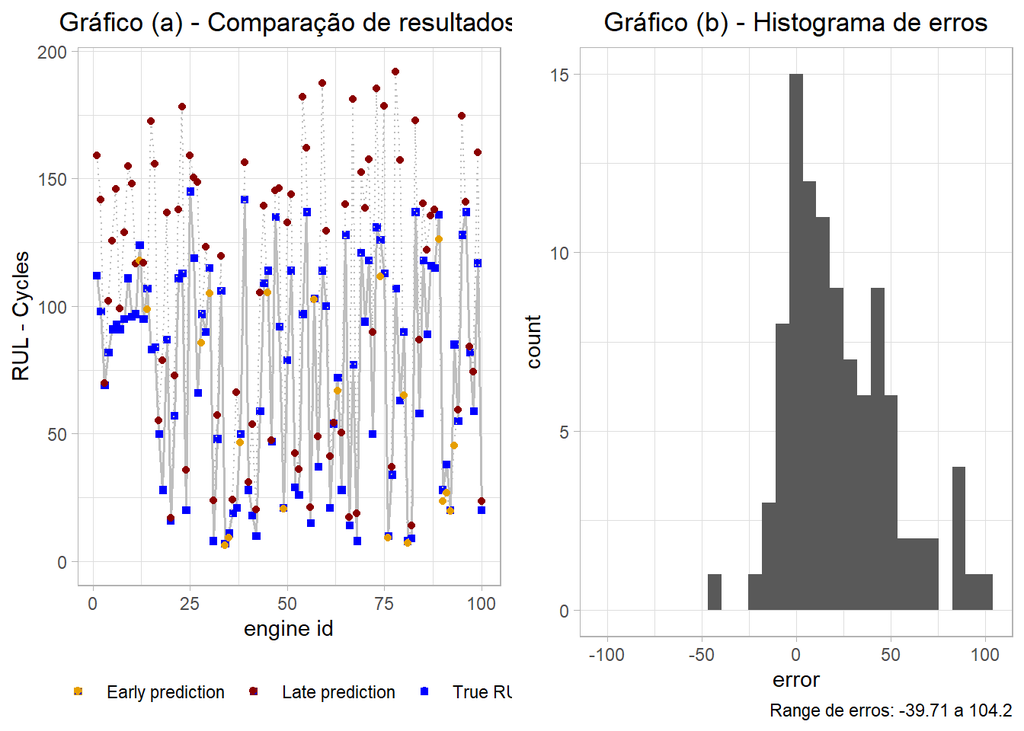

```r
#Compilação dos resultados
results_rf <- tibble(engine_id = 1:100,
                  method = "Random Forest",
                  y_true = y_test_true_end,
                  y_pred = y_test_rf_end,
                  prediction_type = case_when(y_pred>y_true ~ "Late prediction",
                                              y_pred<y_true ~ "Early prediction"),
                  error = y_pred - y_true
                  )%>%
  mutate(status = case_when(y_true < 50 ~ "Critical",y_true >= 50 ~ "Non Critical"))


results <- rbind(results, results_rf)

plot_results(results_rf, "Random Forest")
```

### Redes neurais - Time series

#### Função gerador

Criação de função de geração das bases de dados para formatá-la e prepará-la para uso no algoritmo do LSTM. Ver: https://stackoverflow.com/questions/53357901/using-a-custom-r-generator-function-with-fit-generator-keras-r https://blogs.rstudio.com/ai/posts/2017-12-20-time-series-forecasting-with-recurrent-neural-networks/

```r
data <- data.matrix(train_scaled[,])

generator <- function(data, lookback, delay, max_index, min_index,
                      shuffle = FALSE, batch_size, step, reset = FALSE) {

  # Definição das linhas a serem selecionadas
  if (is.null(max_index))
    max_index <- nrow(data) - delay  - lookback
  i <- min_index + lookback
  function() {
    if (shuffle) {
      rows <- sample(c((min_index+lookback):max_index), size = batch_size)
    }
    else {
      if (i + batch_size >= max_index){
      rows <- c(i:max_index)
      i <<- min_index + lookback
      } else if (data[[i]] == data[[min(i+batch_size-1, max_index)]]){
      rows <- c(i:min(i+batch_size-1, max_index))
      i <<- i + step
      } else {
      engine_id <- data[[i]]
      max_index_id <- max(which(data[,1] == engine_id, arr.ind = T))
      rows <- c(i:min(i+batch_size-1, max_index,max_index_id))
      i <<- min(i+step, max_index, max_index_id+1)
      }
      #i <<- i + step
    }

    samples <- array(0, dim = c(length(rows),
                                1,
                                dim(data)[[-1]]-3))
    targets <- array(0, dim = c(length(rows)))

# Obtenção das amostras e targets
    for (j in 1:length(rows)) {
      indices <- seq(rows[[j]] - lookback,rows[[j]]-1,length.out = dim(samples)[[2]])
      samples[j,,] <- data[indices,3:15]
      targets[[j]] <- data[rows[[j]] + delay,ncol(data)]
    }
    list(samples, targets)
  }
}

# Definição dos parâmetros do gerador
lookback <- 0
delay <- 0
batch_size <- 15
step <- 15



# Definição de parâmetros da rede neural
steps_per_epoch <- as.numeric(train_scaled %>%
  filter(engine_id <= 80) %>%
  group_by(engine_id) %>%
  summarise(contagem = n()) %>%
  mutate(n_batches = ceiling(contagem/batch_size)) %>%
  ungroup() %>%
  summarise(soma1 = sum(n_batches)))

val_steps <- as.numeric(train_scaled %>%
  filter(engine_id > 80) %>%
  group_by(engine_id) %>%
  summarise(contagem = n()) %>%
  mutate(n_batches = ceiling(contagem/batch_size)) %>%
  ungroup() %>%
  summarise(soma1 = sum(n_batches)))

test_steps <- as.numeric(test_scaled %>%
  group_by(engine_id) %>%
  summarise(contagem = n()) %>%
  mutate(n_batches = ceiling(contagem/batch_size)) %>%
  ungroup() %>%
  summarise(soma1 = sum(n_batches)))
```

### Criação do modelo LSTM

```r
nodes = 60

lstm_model <- keras_model_sequential() %>%
  layer_lstm(units = nodes,
             input_shape = list(NULL, dim(data)[[-1]]-3),
             dropout = 0.2, recurrent_dropout = 0.2,
             return_sequences = TRUE) %>%
  layer_lstm(units = nodes,
             dropout = 0.2, recurrent_dropout = 0.2,
             return_sequences = TRUE) %>%
  layer_lstm(units = nodes,
             dropout = 0.2, recurrent_dropout = 0.2,
             return_sequences = TRUE) %>%
  layer_dense(units = nodes, activation ="relu") %>%
  layer_dropout(rate = 0.2) %>%
  layer_dense(units = nodes, activation ="relu") %>%
  layer_dropout(rate = 0.2) %>%
  layer_dense(units = 1)

lstm_model %>% compile(
  optimizer = optimizer_adam(learning_rate = 0.02),
  loss = loss_mean_squared_error()
  )

summary(lstm_model)
```

```
## Model: "sequential"
## ________________________________________________________________________________
##  Layer (type)                       Output Shape                    Param #
## ================================================================================
##  lstm_2 (LSTM)                      (None, None, 60)                17760
##  lstm_1 (LSTM)                      (None, None, 60)                29040
##  lstm (LSTM)                        (None, None, 60)                29040
##  dense_2 (Dense)                    (None, None, 60)                3660
##  dropout_1 (Dropout)                (None, None, 60)                0
##  dense_1 (Dense)                    (None, None, 60)                3660
##  dropout (Dropout)                  (None, None, 60)                0
##  dense (Dense)                      (None, None, 1)                 61
## ================================================================================
## Total params: 83,221
## Trainable params: 83,221
## Non-trainable params: 0
## ________________________________________________________________________________
```

Treinamento do modelo

```r
# Gerador da base de treinamento (Motores 1 - 80 da base de treino)
train_gen <- generator(
  data,
  lookback = lookback,
  delay = delay,
  min_index = 1,
  max_index = max(which(data[,1] == 80, arr.ind = T)),
  shuffle = FALSE,
  step = step,
  batch_size = batch_size)

# Gerador da base de validação (Motores 81 - 100 da base de treino)
val_gen <- generator(
  data,
  lookback = lookback,
  delay = delay,
  min_index = max(which(data[,1] == 80, arr.ind = T))+1,
  max_index = max(which(data[,1] == 100, arr.ind = T)),
  shuffle = FALSE,
  step = step,
  batch_size = batch_size
)


history <- lstm_model %>% fit_generator(
  train_gen,
  steps_per_epoch = steps_per_epoch,
  epochs = 25,
  verbose = 1,
  validation_data = val_gen,
  validation_steps = val_steps
)
```

Análise do modelo treinado

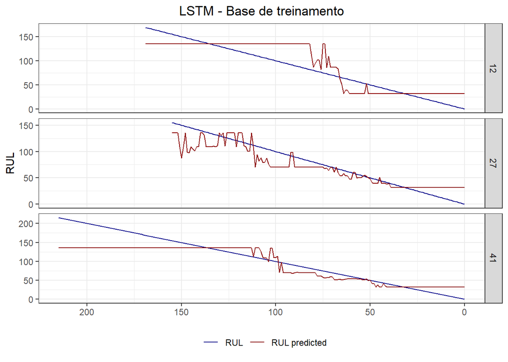

```r
# Gerador da base de treinamento (Motores 1 - 80 da base de treino)
train_gen <- generator(
  data,
  lookback = lookback,
  delay = delay,
  min_index = 1,
  max_index = max(which(data[,1] == 80, arr.ind = T)),
  shuffle = FALSE,
  step = step,
  batch_size = batch_size)

y_train_lstm <- predict_generator(
  lstm_model,
  train_gen,
  steps = steps_per_epoch-1)


y_train_true <- train_scaled %>%
  filter(engine_id <= 80) %>%
  select(engine_id, RUL)

n_rows <- min(dim(y_train_lstm)[1], dim(y_train_true)[1])
train_LSTM_RUL <- as_tibble(cbind(y_train_true[1:n_rows,],
                                  RUL_pred = y_train_lstm[1:n_rows,1,1]))

engine_samples <- c(41,27,12)
train_LSTM_RUL %>% filter(engine_id %in% engine_samples) %>%
  ggplot(aes(x=RUL))+
  geom_line(aes(y=RUL, color = "RUL"))+
  geom_line(aes(y=RUL_pred,color = paste0("RUL predicted")))+
  scale_x_reverse()+
  labs(x = NULL, title = "LSTM - Base de treinamento")+
  scale_colour_manual(" ", values=c("darkblue", "darkred"))+
  theme_bw()+
  theme(legend.position = "bottom",legend.title = element_blank(), legend.key=element_blank(),plot.title = element_text(hjust = 0.5))+
  facet_grid(rows = vars(engine_id), scales ="free")
```

```r
func_score(as.numeric(train_LSTM_RUL$RUL), as.numeric(train_LSTM_RUL$RUL_pred))
```

```
## Mean Absolute Error: 31.06
## Root Mean Squared Error: 42.81
```

Aplicação do modelo na base de teste

```r
# Gerador da base de teste
data_test <- data.matrix(test_scaled[,])

test_gen <- generator(
  data_test,
  lookback = lookback,
  delay = delay,
  min_index = 1,
  max_index = NULL,
  shuffle = FALSE,
  step = step,
  batch_size = batch_size
)

y_test_lstm <- predict_generator(
  lstm_model,
  test_gen,
  steps = test_steps)


y_test_true <- test_scaled %>% select(engine_id, RUL)
dim(y_test_lstm)[1] == dim(y_test_true)[1]
```

```
## [1] TRUE
```

```r
n_rows <- min(dim(y_test_lstm)[1], dim(y_test_true)[1])
test_LSTM_RUL <- as_tibble(cbind(y_test_true[1:n_rows,], RUL_pred = y_test_lstm[1:n_rows,1,1]))

#Análise dos resultados da base de teste - RUL último ciclo
y_test_LSTM_end <- test_LSTM_RUL %>%
  group_by(engine_id) %>%
  mutate(min = min(RUL), check = RUL - min) %>%
  filter(check == 0)

y_test_true_end <- as.numeric(test_end_cycle$RUL)
func_score(y_test_LSTM_end$RUL,y_test_LSTM_end$RUL_pred, tipo = "teste")
```

```
## Score: 4812.8
## Mean Absolute Error: 22.07
## Root Mean Squared Error: 27.87
```

### Lstm model (2)

RUL alvo modificada de uma função linear para uma linear por partes.

```r
lstm_model2 <- keras_model_sequential() %>%
  layer_lstm(units = nodes,
             input_shape = list(NULL, dim(data)[[-1]]-3),
             dropout = 0.2, recurrent_dropout = 0.2,
             return_sequences = TRUE) %>%
  layer_lstm(units = nodes,
             dropout = 0.2, recurrent_dropout = 0.2,
             return_sequences = TRUE) %>%
  layer_lstm(units = nodes,
             dropout = 0.2, recurrent_dropout = 0.2,
             return_sequences = TRUE) %>%
  layer_dense(units = nodes, activation ="relu") %>%
  layer_dropout(rate = 0.2) %>%
  layer_dense(units = nodes, activation ="relu") %>%
  layer_dropout(rate = 0.2) %>%
  layer_dense(units = 1)

lstm_model2 %>% compile(
  optimizer = optimizer_adam(learning_rate = 0.02),
  loss = loss_mean_squared_error()
  )

summary(lstm_model2)
```

```
## Model: "sequential_1"
## ________________________________________________________________________________
##  Layer (type)                       Output Shape                    Param #
## ================================================================================
##  lstm_5 (LSTM)                      (None, None, 60)                17760
##  lstm_4 (LSTM)                      (None, None, 60)                29040
##  lstm_3 (LSTM)                      (None, None, 60)                29040
##  dense_5 (Dense)                    (None, None, 60)                3660
##  dropout_3 (Dropout)                (None, None, 60)                0
##  dense_4 (Dense)                    (None, None, 60)                3660
##  dropout_2 (Dropout)                (None, None, 60)                0
##  dense_3 (Dense)                    (None, None, 1)                 61
## ================================================================================
## Total params: 83,221
## Trainable params: 83,221
## Non-trainable params: 0
## ________________________________________________________________________________
```

Treinamento do modelo

```r
train_scaled2 <- train_scaled %>% mutate(RUL = ifelse(RUL >= 130, 130, RUL))

data2 <- data.matrix(train_scaled2[,])
# Gerador da base de treinamento (Motores 1 - 80 da base de treino)
train_gen2 <- generator(
  data2,
  lookback = lookback,
  delay = delay,
  min_index = 1,
  max_index = max(which(data[,1] == 80, arr.ind = T)),
  shuffle = FALSE,
  step = step,
  batch_size = batch_size
)

# Gerador da base de validação (Motores 81 - 100 da base de treino)
val_gen2 <- generator(
  data2,
  lookback = lookback,
  delay = delay,
  min_index = max(which(data[,1] == 80, arr.ind = T))+1,
  max_index = max(which(data[,1] == 100, arr.ind = T)),
  shuffle = FALSE,
  step = step,
  batch_size = batch_size
)


history2 <- lstm_model2 %>% fit_generator(
  train_gen2,
  steps_per_epoch = steps_per_epoch,
  epochs = 25,
  verbose = 1,
  validation_data = val_gen2,
  validation_steps = val_steps
)
```

Análise do modelo treinado

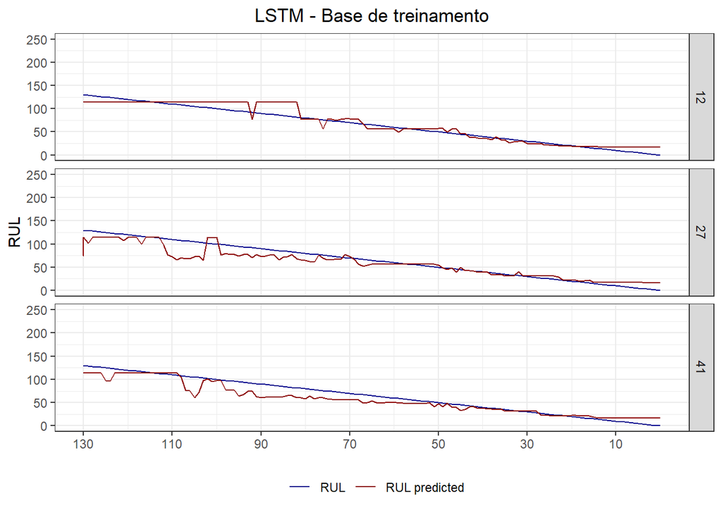

```r
train_gen2 <- generator(
  data2,
  lookback = lookback,
  delay = delay,
  min_index = 1,
  max_index = max(which(data[,1] == 80, arr.ind = T)),
  shuffle = FALSE,
  step = step,
  batch_size = batch_size
)


y_train_lstm2 <- predict_generator(
  lstm_model2,
  train_gen2,
  steps = steps_per_epoch-1)


#Check de consistência da quantidade de variáveis preditas
y_train_true <- train_scaled2 %>% filter(engine_id <= 80) %>% select(engine_id, RUL)
n_rows <- min(dim(y_train_lstm2)[1], dim(y_train_true)[1])

train_LSTM_RUL2 <- as_tibble(cbind(y_train_true[1:n_rows,], RUL_pred = y_train_lstm2[1:n_rows,1,1]))

engine_samples <- c(41,27,12)
train_LSTM_RUL2 %>% filter(engine_id %in% engine_samples) %>%
  ggplot(aes(x=RUL))+
  geom_line(aes(y=RUL, color = "RUL"))+
  geom_line(aes(y=RUL_pred,color = paste0("RUL predicted")))+
  scale_x_reverse(breaks = seq(250,0,-20))+
  scale_y_continuous(limits = c(0,250))+
  labs(x = NULL, title = "LSTM - Base de treinamento")+
  scale_colour_manual(" ", values=c("darkblue", "darkred"))+
  theme_bw()+
  theme(legend.position = "bottom",
        legend.title = element_blank(),
        legend.key=element_blank(),
        plot.title = element_text(hjust = 0.5))+
  facet_grid(rows = vars(engine_id))
```

```r
func_score(as.numeric(train_LSTM_RUL2$RUL), as.numeric(train_LSTM_RUL2$RUL_pred))
```

```
## Mean Absolute Error: 16.29
## Root Mean Squared Error: 20.54
```

Aplicação do modelo na base de teste

```r
test_gen <- generator(
  data_test,
  lookback = lookback,
  delay = delay,
  min_index = 1,
  max_index = NULL,
  shuffle = FALSE,
  step = step,
  batch_size = batch_size
)

y_test_lstm2 <- predict_generator(
  lstm_model2,
  test_gen,
  steps = test_steps)


y_test_true <- test_scaled %>% select(engine_id, RUL)
dim(y_test_lstm2)[1] == dim(y_test_true)[1]
```

```
## [1] TRUE
```

```r
n_rows <- min(dim(y_test_lstm2)[1], dim(y_test_true)[1])

test_LSTM_RUL2 <- as_tibble(cbind(y_test_true[1:n_rows,], RUL_pred = y_test_lstm2[1:n_rows,1,1]))

#Análise dos resultados da base de teste - RUL último ciclo
y_test_LSTM_end2 <- test_LSTM_RUL2 %>%
  group_by(engine_id) %>%
  mutate(min = min(RUL), check = RUL - min) %>%
  filter(check == 0)

func_score(y_test_LSTM_end2$RUL,y_test_LSTM_end2$RUL_pred, tipo = "teste")
```

```
## Score: 897.71
## Mean Absolute Error: 14.36
## Root Mean Squared Error: 19.69
```

# Compilação dos resultados

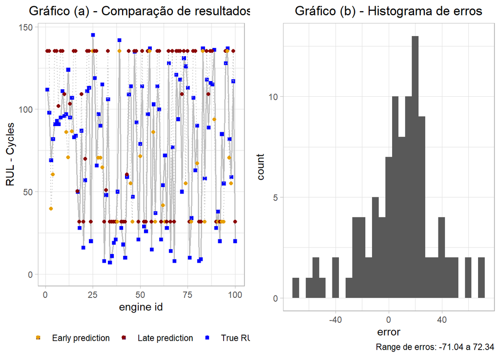

```r
#O conjunto de observações em que a RUL real é inferior a 50 ciclos é considerado como o conjunto crítico em que um algoritmo de predição de vida remanescente precisa ser mais preciso, já que são ativos em estado de falha iminente.

results_lstm <- tibble(engine_id = 1:100,
                  method = "LSTM 1",
                  y_true = y_test_LSTM_end$RUL,
                  y_pred = y_test_LSTM_end$RUL_pred,
                  prediction_type = case_when(y_pred>y_true ~ "Late prediction",
                                              y_pred<y_true ~ "Early prediction"),
                  error = y_pred - y_true
                  ) %>%
   mutate(status = case_when(y_true < 50 ~ "Critical",y_true >= 50 ~ "Non Critical"))

results_lstm2 <- tibble(engine_id = 1:100,
                  method = "LSTM 2",
                  y_true = y_test_LSTM_end2$RUL,
                  y_pred = y_test_LSTM_end2$RUL_pred,
                  prediction_type = case_when(y_pred>y_true ~ "Late prediction",
                                              y_pred<y_true ~ "Early prediction"),
                  error = y_pred - y_true
                  )  %>%
  mutate(status = case_when(y_true < 50 ~ "Critical",y_true >= 50 ~ "Non Critical"))

results <- rbind(results, results_lstm,results_lstm2)

plot_results(results,  "LSTM 1")
```

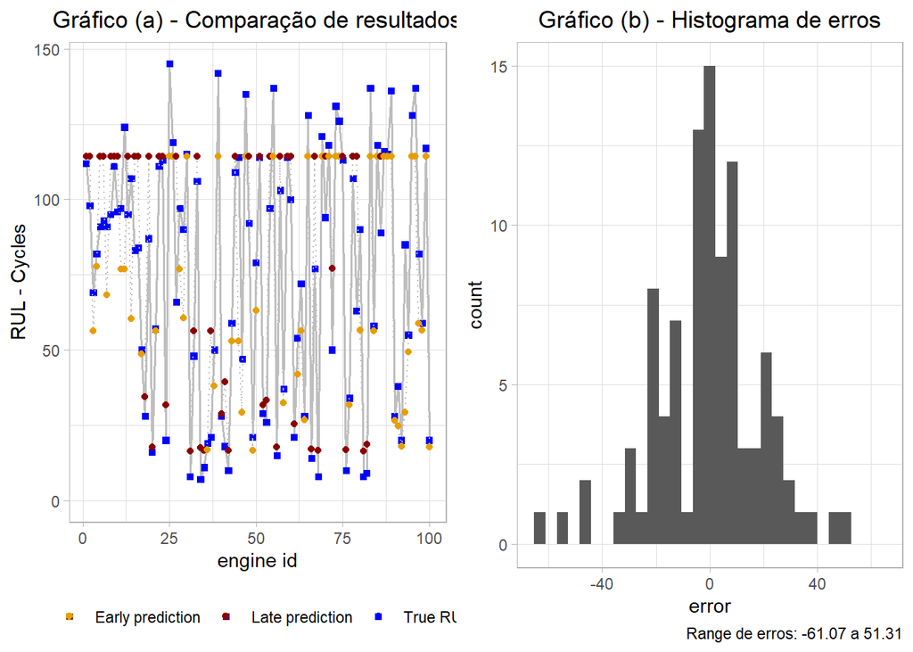

```r
plot_results(results, "LSTM 2")
```

```r
results <- results %>% mutate(status = case_when(y_true < 50 ~ "Critical",
                                                 y_true >= 50 ~ "Non Critical"))
results_critical <- results %>% filter(status == "Critical")
```

### Análise para todos os motores e para o conjunto de motores “críticos”

```r
methods <- c("Modelo base", "Random Forest", "LSTM 1", "LSTM 2")
df <- tibble()

#Resultados para todos os motores
cat(paste("Resultados compilados",sep = "\n"))
```

```
## Resultados compilados
```

```r
for (metodo in methods) {
  df <- results %>% filter(method == metodo)
  print(noquote(""))
  print(paste0("Para o método ", metodo, ", os resultados foram:"))
  func_score(df$y_true,df$y_pred, tipo = "teste")
}
```

```
## [1]
## [1] "Para o método Modelo base, os resultados foram:"
## Score: 25454.54
## Mean Absolute Error: 31.83
## Root Mean Squared Error: 40.05[1]
## [1] "Para o método Random Forest, os resultados foram:"
## Score: 74268.16
## Mean Absolute Error: 26.43
## Root Mean Squared Error: 36.1[1]
## [1] "Para o método LSTM 1, os resultados foram:"
## Score: 4812.8
## Mean Absolute Error: 22.07
## Root Mean Squared Error: 27.87[1]
## [1] "Para o método LSTM 2, os resultados foram:"
## Score: 897.71
## Mean Absolute Error: 14.36
## Root Mean Squared Error: 19.69
```

```r
#Resultados para os motores críticos
cat(paste("Resultados dos motores críticos, RUL <= 50 ciclos",sep = "\n"))
```

```
## Resultados dos motores críticos, RUL <= 50 ciclos
```

```r
for (metodo in methods) {
  df <- results_critical %>% filter(method == metodo)
  print(noquote(""))
  print(paste0("Para o método ", metodo, ", os resultados foram:"))
  func_score(df$y_true,df$y_pred, tipo = "teste")
}
```

```
## [1]
## [1] "Para o método Modelo base, os resultados foram:"
## Score: 2192.81
## Mean Absolute Error: 24.37
## Root Mean Squared Error: 31.18[1]
## [1] "Para o método Random Forest, os resultados foram:"
## Score: 326.22
## Mean Absolute Error: 10.73
## Root Mean Squared Error: 16.64[1]
## [1] "Para o método LSTM 1, os resultados foram:"
## Score: 110.49
## Mean Absolute Error: 12.82
## Root Mean Squared Error: 14.86[1]
## [1] "Para o método LSTM 2, os resultados foram:"
## Score: 65.06
## Mean Absolute Error: 7.4
## Root Mean Squared Error: 10.26
```

### Histograma de erros - Motores críticos

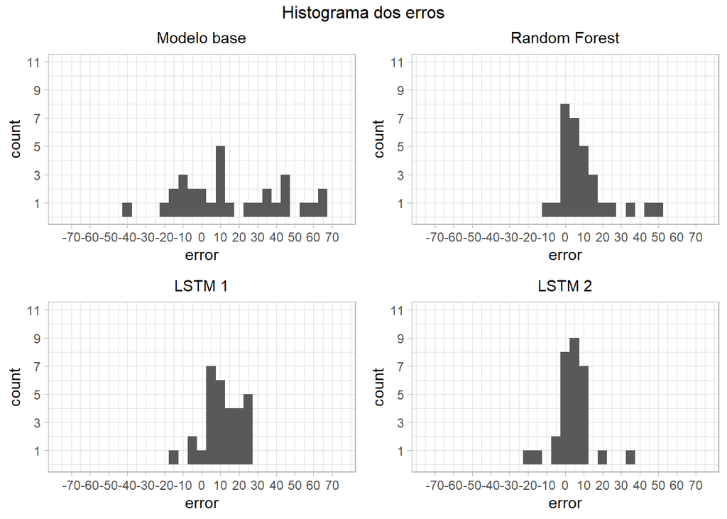

```r
hist_list <- list()
for (metodo in methods){
  df <- results_critical %>% filter(method == metodo)
  hist_list[[paste0("Histograma de erros - ", metodo)]] <- df %>%
  ggplot(mapping = aes( error)) +
  geom_histogram(show.legend = FALSE, binwidth = 5)+
  theme_bw(base_size=8)+
  labs(subtitle = df$method)+
  theme_light() +
  theme(plot.subtitle = element_text(hjust = 0.5))+
  scale_x_continuous(limits = ~ c(-1, 1) * max(abs(.x)), breaks = seq(-70,70,10))+
  scale_y_continuous(breaks=seq(1,11,2)) +
  coord_cartesian(ylim = c(0,11), xlim=c(-75,75))
  }

do.call("grid.arrange", c(hist_list, top = "Histograma dos erros"))
```